# Cours informatique - Regression linéaire

# Régression linéaire : partie 1

## Extensions

Installez l’extension `ISLR2` et `car` contenant les jeux de données et les fonctions qui nous intéressent.

## Régression linéaire simple

```r
head(Boston)
```

|  | crim | zn | indus | chas | nox | rm | age | dis | rad | tax | ptratio | lstat | medv |
| --- | --- | --- | --- | --- | --- | --- | --- | --- | --- | --- | --- | --- | --- |
| 1 | 0.00632 | 18 | 2.31 | 0 | 0.538 | 6.575 | 65.2 | 4.0900 | 1 | 296 | 15.3 | 4.98 | 24.0 |
| 2 | 0.02731 | 0 | 7.07 | 0 | 0.469 | 6.421 | 78.9 | 4.9671 | 2 | 242 | 17.8 | 9.14 | 21.6 |
| 3 | 0.02729 | 0 | 7.07 | 0 | 0.469 | 7.185 | 61.1 | 4.9671 | 2 | 242 | 17.8 | 4.03 | 34.7 |
| 4 | 0.03237 | 0 | 2.18 | 0 | 0.458 | 6.998 | 45.8 | 6.0622 | 3 | 222 | 18.7 | 2.94 | 33.4 |
| 5 | 0.06905 | 0 | 2.18 | 0 | 0.458 | 7.147 | 54.2 | 6.0622 | 3 | 222 | 18.7 | 5.33 | 36.2 |
| 6 | 0.02985 | 0 | 2.18 | 0 | 0.458 | 6.430 | 58.7 | 6.0622 | 3 | 222 | 18.7 | 5.21 | 28.7 |

```r
str(Boston)
```

```
## 'data.frame':    506 obs. of  13 variables:
##  $ crim   : num  0.00632 0.02731 0.02729 0.03237 0.06905 ...
##  $ zn     : num  18 0 0 0 0 0 12.5 12.5 12.5 12.5 ...
##  $ indus  : num  2.31 7.07 7.07 2.18 2.18 2.18 7.87 7.87 7.87 7.87 ...
##  $ chas   : int  0 0 0 0 0 0 0 0 0 0 ...
##  $ nox    : num  0.538 0.469 0.469 0.458 0.458 0.458 0.524 0.524 0.524 0.524 ...
##  $ rm     : num  6.58 6.42 7.18 7 7.15 ...
##  $ age    : num  65.2 78.9 61.1 45.8 54.2 58.7 66.6 96.1 100 85.9 ...
##  $ dis    : num  4.09 4.97 4.97 6.06 6.06 ...
##  $ rad    : int  1 2 2 3 3 3 5 5 5 5 ...
##  $ tax    : num  296 242 242 222 222 222 311 311 311 311 ...
##  $ ptratio: num  15.3 17.8 17.8 18.7 18.7 18.7 15.2 15.2 15.2 15.2 ...
##  $ lstat  : num  4.98 9.14 4.03 2.94 5.33 ...
##  $ medv   : num  24 21.6 34.7 33.4 36.2 28.7 22.9 27.1 16.5 18.9 ...
```

La fonction `attach` permet d’importer les variables d’un tableau de données dans votre environnement. Par exemple, après avoir utilisé `attach`, `Boston$age` pourra être accessible en utilisant la variable `age` importée.

```r
attach(Boston)
```

Avant d’entrainer notre modèle de régression linéaire, nous pouvons observer avec `plot()` s’il existe une relation linéaire entre la variable à prédire et la variable explicative.

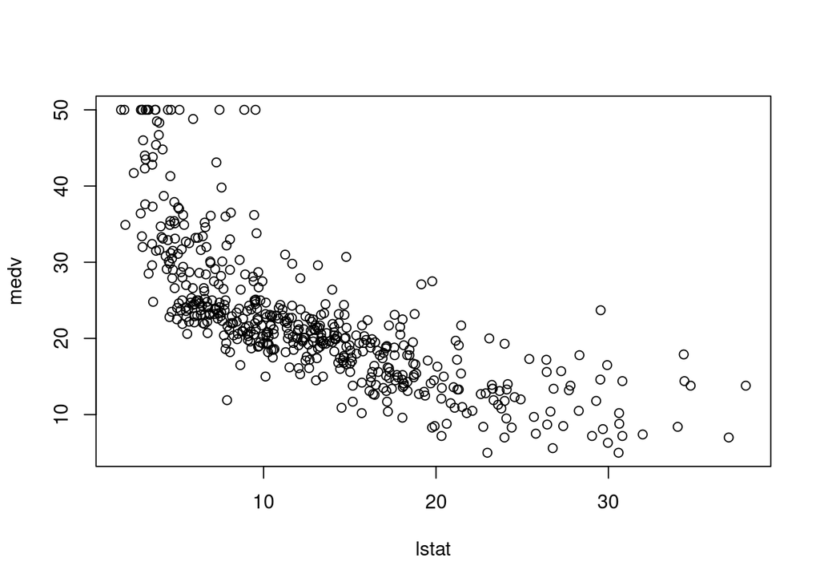

```r
plot(lstat, medv)
```

Nous utilisons la fonction `lm()` pour l’entrainement d’un modèle de régression linéaire simple à partir de la variable explicative `lstat` pour prédire la variable `medv`.

```r
lm.fit <- lm(medv ~ lstat, data = Boston)
```

La fonction `summary(lm.fit)` retourne les $p$-valeurs et les écarts types des coefficients (`a` et `b`) ainsi que les statistiques $R^2$ et $F$ du modèle de régression.

```r
lm.fit
```

```
##
## Call:
## lm(formula = medv ~ lstat, data = Boston)
##
## Coefficients:
## (Intercept)        lstat
##       34.55        -0.95
```

```r
summary(lm.fit)
```

```
##
## Call:
## lm(formula = medv ~ lstat, data = Boston)
##
## Residuals:
##     Min      1Q  Median      3Q     Max
## -15.168  -3.990  -1.318   2.034  24.500
##
## Coefficients:
##             Estimate Std. Error t value Pr(>|t|)
## (Intercept) 34.55384    0.56263   61.41   <2e-16 ***
## lstat       -0.95005    0.03873  -24.53   <2e-16 ***
## ---
## Signif. codes:  0 '***' 0.001 '**' 0.01 '*' 0.05 '.' 0.1 ' ' 1
##
## Residual standard error: 6.216 on 504 degrees of freedom
## Multiple R-squared:  0.5441, Adjusted R-squared:  0.5432
## F-statistic: 601.6 on 1 and 504 DF,  p-value: < 2.2e-16
```

Interpretez les résultats retournés par la fonction `summary(lm.fit)`.

On utilise la fonction `names()` pour connaitre les informations stockées dans `lm.fit`.

```r
names(lm.fit)
```

```
##  [1] "coefficients"  "residuals"     "effects"       "rank"
##  [5] "fitted.values" "assign"        "qr"            "df.residual"
##  [9] "xlevels"       "call"          "terms"         "model"
```

```r
lm.fit$coefficients
```

```
## (Intercept)       lstat
##  34.5538409  -0.9500494
```

Si nous voulons prédire 3 nouvelles valeurs de `lstat` (5, 10 et 15) avec la fonction `predict()` :

```r
predict(lm.fit, data.frame(lstat = (c(5, 10, 15))))
```

```
##        1        2        3
## 29.80359 25.05335 20.30310
```

Nous affichons la droite de régression entre `medv` et `lstat` en utilisant la fonction `abline()`.

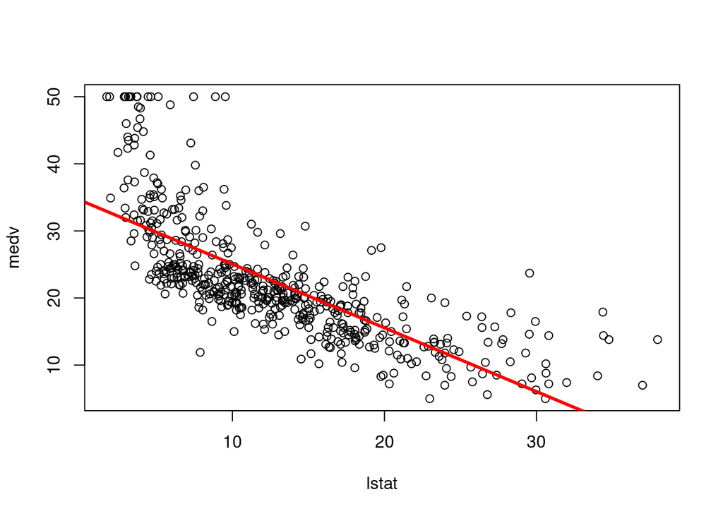

```r
plot(lstat, medv)
abline(lm.fit, lwd = 3, col ="red")
```

Nous observons qu’il pourrait y avoir une relation non-linéaire entre `lstat` et `medv`.

## Aller plus loin

- Prendre en compte la non-linéarité entre la variable à prédire et les variables explicatives (transformation non-linéaire des variables explicatives)
- Effectuer une régression sur plusieurs variables (prendre en compte la totalité des variables explicatives de notre jeu de données, et pas seulement `lstat`)

Par exemple, si nous voulons utiliser `lstat` et `age` :

```r
lm.fit <- lm(medv ~ lstat + age, data = Boston)
```

- Vérifier les 4 hypothèses du modèle de régression linéaire (linéarité du modèle, normalité, indépendance et homoscédasticité des erreurs)

Des idées pour aborder ces problèmes ?